# Who targets you..

… during the 2021 parliamentary elections in Germany?

Facebook provides a host of targeting opportunities to political advertisers seeking to communicate their message to an online audience. With data collected by Who Targets Me, we can explore how political actors target audiences during the 2021 German parliamentary elections.

Roughly 5000 users of the Who Targets Me browser app in Germany provide us with a constant stream of data about political ads on Facebook. In total, over 90.000 political ads were seen between April 26th and August 3rd 2021. Each time an ad appears in someones timeline we also call this an an *impression*. An important source of information in our data is the ‘Why am I seeing this?’ label which accompanies each ad and tells us why a specific user has seen the ad. Contrary to the Facebook ad library, which does not provide this kind of information, the *Why am I seeing this?* label reveals what criteria exactly the advertisers wanted to target.

For the following visualizations we consider only the following (most common) targeting criteria:

**GENDER:** Ads that were targeted by gender.

**AGE:** Ads that were targeted by age.

**INTERESTS:** Ads that were targeted by interests.

**LOCATION:** Ads that were targeted by location.

**CUSTOM AUDIENCE:** Ads that were targeted using a custom audience.

**BEHAVIOUR:** Ads that were targeted to some behaviour.

**JOB/EDUCATION:** Ads that targeted a job/employer or school/education level.

Our dataset classifies all party and candidate Facebook accounts as belonging to their respective party, be it on the local, state or federal level. That means: Armin Laschet, chancellor candidate for the CDU, the official CSU Facebook account and the Berlin branch of the CDU party *CDU Berlin*, are all classified as belonging to the party block of the CDU/CSU.

## Top 20 Targeting Criteria of Political Parties Facebook accounts

[figure not shown]

*Figure 1: Most common impressions with targeting criteria*

In order to gauge which targeting criteria are most frequently used by which party, we divide the number of times an ad appeared in a timeline with a certain targeting criteria by the the total number of targeted impressions received by a party. This gives us a measure of relative importance of targeting criteria per party. So for example, we can observe that the most commonly occurring targeting criteria for FDP accounts is a location: Berlin, which makes up 12.5% of all targeted impressions for the FDP.

Figure 1 visualizes this targeting importance measure for six political parties: the **CDU/CSU**, **AfD**, **FDP**, **SPD**, **Bündnis 90/Die Grünen** and **Die LINKE**. We can observe that targeting interest in its own party seems to be a very common strategy (within the top 3) among all political parties, except for the Greens (Bündnis 90/Die Grünen) who seem to focus more on issues like environmental protection (“Umweltschutz”) or renewable energy (“Erneuerbare Energien”).

This suggests that political parties predominantly use Facebook targeting to mobilize voters who are already interested in their party or what they stand for rather than persuading new voters, a finding that academic research into online targeting has already hinted at.[^2] [^3]

However, there is also some evidence for more aggressive targeting: Die LINKE (“the left”) not only frequently targets interest in its own party and politicians but also people who are interested in the SPD (social democrats). The social democrats have been in free fall for years now and it seems like the Left wants to profit off of that fact by targeting some of the potentially disaffected voters of the SPD.

There is also more ambiguous targeting for which we can only make an educated guess about its intention: Parties like the FDP, CDU/CSU and to a lesser extent the SPD and AfD seem to often rely on so-called *custom audience* targeting. The most frequently utilized method here is the *lookalike audience*, whereby the political advertiser defines a target audience (for example by uploading a list of E-Mails, or people who engage with content on their page or website) and Facebook helps identify people who are similar to them (in terms of interest, demographics etc.). Of course, if a custom audience consists of an E-Mail list of volunteers or people who engaged with the party page before, it can be seen as yet another effort to simply mobilize voters rather than persuading new people.

## Targeting Networks

However, the charts so far only tell us something about the frequency of *individual* targeting methods. Yet, any combination of these criteria is possible. One possible way to explore the relationship between all the targeting criteria used is to use a *network visualization*.

When looking at the *network visualization*, the circles are targeting criteria (age, gender, interests, etc) and the squares are political accounts using these criteria to target ads. The more ads with a certain targeting criterium were seen by our sample (*impressions*), the greater the size of the circle. Similarly, the greater the size of the square, the more ads by this advertiser were seen by our sample (targeted or not). The thickness of the connection between the squares and dots show how often this targeting combination appeared in our user sample.

### Targeting Networks of CDU/CSU

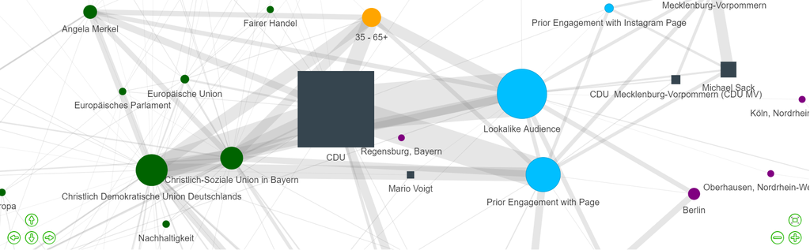

*Figure 2: CDU/CSU often targets interest in its own party and Angela Merkel*

Figure 2 shows that the CDU/CSU targets interests in CSU, CDU and Angela Merkel, which often coincide with targeting voters that are 35 or older.

### Targeting conspiracy and extremist interests

As we have already seen from the data so far, Facebook allows some very detailed targeting. Some potential targeting criteria might be more problematic than others though. Facebook allowing ads to be targeted towards extremist interest is unfortunately not a new story. In an especially egregious example, [journalists discovered](https://theintercept.com/2018/11/02/facebook-ads-white-supremacy-pittsburgh-shooting/) that Facebook had allowed ads targeted at people with interest in “white genocide”, a far-right conspiracy theory.

In our data, we discovered that *Die LINKE* politician Dieter Dehm, [who has been accused of flirting with corona-related conspiracy theories before](https://taz.de/Umstrittener-Song-von-Diether-Dehm/!5706949/), engaged in some questionable targeting enabled through the Facebook ad delivery system. The Bundestag member ran political ads targeted at people with interests in the far-right publication [Epoch Times](https://newrepublic.com/article/155076/obscure-newspaper-fueling-far-right-europe) and [known conspiracy influencer](https://www.zdf.de/nachrichten/panorama/coronavirus-kenfm-jebsen-faktencheck-100.html) Ken Jebsen (via his show KenFM). See Figure 3 below.

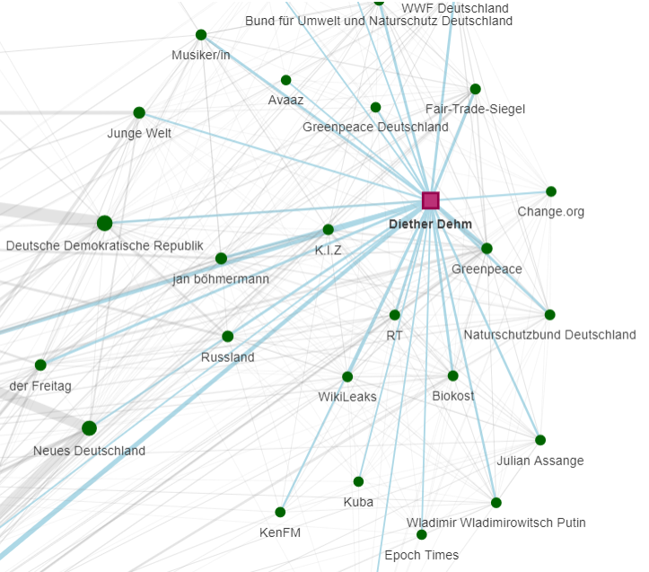

*Figure 3: Politician Dieter Dehm targets far-right and conspiracy interests on Facebook.*

## Check out the data yourself!

If you want to explore the targeting methods yourself, simply check out this [**link to the interactive app**](https://favstats.shinyapps.io/btw21_wtm/).

When you go to the *Details* tab you will also be able to search the text and targeting methods of all the ads in the sample.

[figure not shown]

[^1]: https://www.bundeswahlleiter.de/dam/jcr/390abd1b-20da-4317-b321-195b332c884b/btw17_wista_03-2018.pdf
[^2]: Fowler, E. F., Franz, M. M., Martin, G. J., Peskowitz, Z., & Ridout, T. N. (2021). Political advertising online and offline. American Political Science Review, 115(1), 130-149.
[^3]: Franz, M. M., Franklin Fowler, E., Ridout, T., & Wang, M. Y. (2020). The issue focus of online and television advertising in the 2016 presidential campaign. American Politics Research, 48(1), 175-196.